# 状態空間モデル（12/10）

## 1. 分析例①

### データ

**オフィス街のコンビニにおける緑茶ペットボトルの日次販売本数データ**

- data_tea1.csv：パラメータ推定用データ（2015/04/01 ~ 2015/06/23，84日間）
- data_tea2.csv：予測力検証用データ（2015/06/24 ~ 2015/06/30，7日間）

|  | date | num | day | holiday |
| --- | --- | --- | --- | --- |
| 1 | 20150401 | 229 | 3 | 0 |
| 2 | 20150402 | 249 | 4 | 0 |
| 3 | 20150403 | 267 | 5 | 0 |
| 4 | 20150404 | 109 | 6 | 0 |
| 5 | 20150405 | 79 | 7 | 0 |
| 6 | 20150406 | 263 | 1 | 0 |

| 変数名 | 内容 |
| --- | --- |
| date | 日付 |
| num | 販売本数 $(y_t)$ |
| day | 曜日（1＝月曜，2＝火曜，…，7＝日曜） |
| holiday | 祝日フラグ（1＝祝日，0＝それ以外） $(x_t)$ |

**データ出典**：日経NEED POSデータ

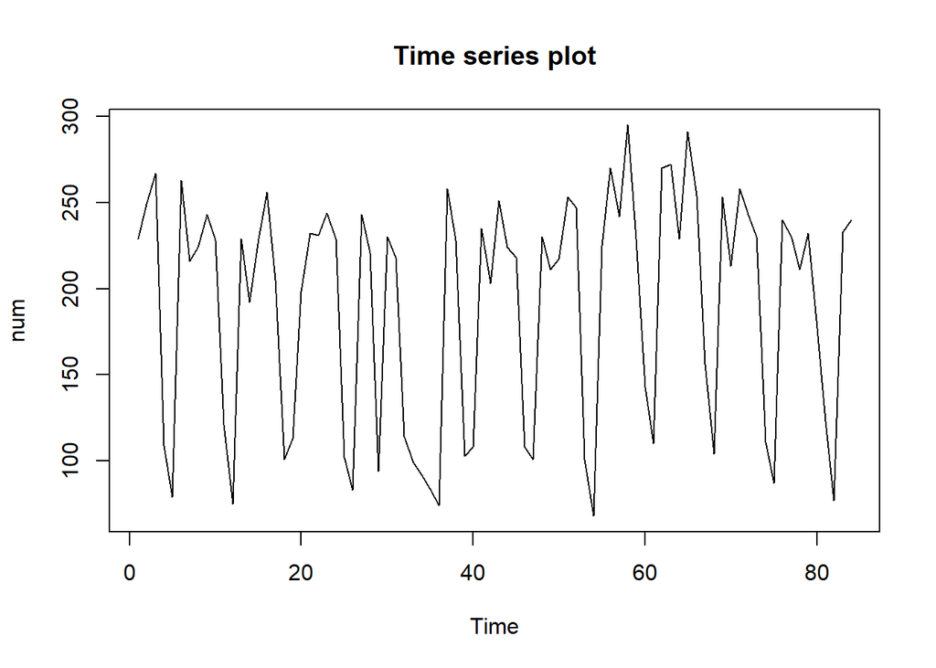

### モデル

#### 観測モデル

$$y_t = \alpha_t + s_t + \beta x_t + \varepsilon_t; \qquad \varepsilon_t \sim N(0, \sigma^2)$$

#### システムモデル

$$\alpha_t = \alpha_{t-1} + v_t; \qquad v_t \sim N(0, \tau^2_\alpha) \\
s_t = -\sum_{j=1}^6 s_{t-j} + \delta_t; \qquad \delta_t \sim N(0, \tau^2_s)$$

### Rコード（推定）

```r
# データ  は "Import Dataset" で読込済みとする
library(KFAS)

# パラメータ推定
model <- SSModel(num ~ SSMtrend(1, Q = NA) +
                   SSMseasonal(7, sea.type = "dummy", Q = NA) +
                   SSMregression(~ holiday, Q = 0),
                 H = NA, data = data_tea1)
fit <- fitSSM(model, inits = rep(0,3))
out <- KFS(fit$model)

## 推定結果の図示
plot.df <- cbind(data_tea1$num, out$alphahat[,1:3])
colnames(plot.df) <- c("sales", "holiday", "trend", "day effect")
plot(plot.df, main = "Estimaion")
```

**`SSModel(formula, H, data)`：モデルの記述・作成**

- **`formula`**：目的変数・説明変数の指定
  - `SSMtrend(1, Q = NA)`：1次のトレンド項
  - `SSMseasonal(7, sea.type = "dummy", Q = NA)`：曜日周期項 ⇒ 月次データなら7を12に変更
  - `SSMregression(~ holiday, Q = 0)`：祝日フラグ
  - `Q = NA` ならシステムモデルの分散を推定（＝時変の係数），`Q = 0` なら分散を0に固定（＝時間不変の係数）
- **`H`**：観測モデルの分散
- **`data`**：観測データの指定

**`fitSSM(model, inits)`：パラメータの推定**

- **`model`**：`SSModel` で作成したモデルの指定
- **`inits`**：推定パラメータの初期値 ⇒ `SSModel` 内の `NA` の数だけ指定（`rep(0,3)` は0を3つ並べる関数）

**`KFS(model)`：カルマンフィルタの実行** - **`model`**：`fitSSM` で推定したモデルの指定

#### Rコードの出力

##### 推定結果の図示

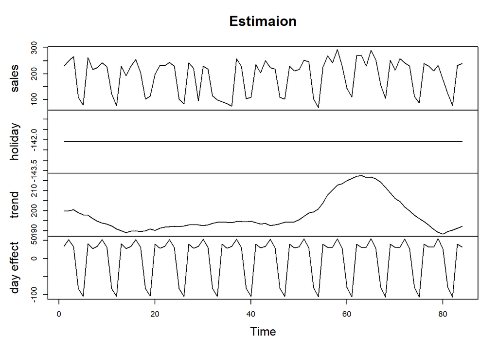

### Rコード（予測）

```r
# 予測用データの作成
newdata <- SSModel(rep(NA, 7) ~ SSMtrend(1, Q = NA) +
                     SSMseasonal(7, sea.type = "dummy", Q = NA) +
                     SSMregression(~ holiday, Q = 0),
                   H = NA, data = data_tea2)
newdata$Q <- fit$model$Q    # fitSSM で推定したシステムモデルの分散の代入
newdata$H <- fit$model$H    # fitSSM で推定した観測モデルの分散の代入

# 1週先予測の実行
pred <- predict(fit$model, newdata = newdata, interval = "prediction", level = 0.95)

## 予測値
pred.df <- cbind(data_tea2$num, pred)
pred.df

## 予測結果の図示
cols = c("black","red","red","red")
ltys = c("solid","solid","dashed","dashed")
plot(pred.df, plot.type = "single",
     col = cols, lty = ltys,
     main = "1 week prediction")
legend("bottomleft", legend = c("実績値", "予測値", "95%区間"),
       col = cols[1:3], lty = ltys[1:3])

## 予測力指標
library(Metrics)
MAPE <- mape(data_tea2$num, pred[, "fit"])
MAE <- mae(data_tea2$num, pred[, "fit"])
print(MAPE)
print(MAE)
```

**`predict(model, newdata, interval, level)`：予測の実行**

- **`model`**：`fitSSM` で推定したモデル
- **`newdata`**：予測用のデータ
  - 予測を行う際にも，予測用の説明変数（今回は祝日フラグ）が入った `SSModel` を作成する必要がある
  - 目的変数（販売本数）は，予測期間分（7日間）の欠損値 `rep(NA, 7)` を指定
  - 分散パラメータは `fitSSM` で推定したものを代入
- **`interval`**：予測の場合は `prediction` を指定
- **`level`**：予測（信頼）区間の指定

#### Rコードの出力

##### 予測値

```
## Time Series:
## Start = 85
## End = 91
## Frequency = 1
##    data_tea2$num  pred.fit  pred.lwr pred.upr
## 85           219 223.98536 185.06308 262.9076
## 86           266 247.22344 207.75847 286.6884
## 87           242 219.01739 178.86093 259.1738
## 88           130 113.41501  72.59368 154.2363
## 89            99  85.03272  43.57552 126.4899
## 90           218 232.47745 190.41946 274.5354
## 91           266 223.83365 181.30662 266.3607
```

- `data_tea2$num`：実績値（実際の販売本数）
- `pred.fit`：予測値
- `pred.lwr`：予測値の下側95％点
- `pred.upr`：予測値の上側95％点

##### 予測結果の図示

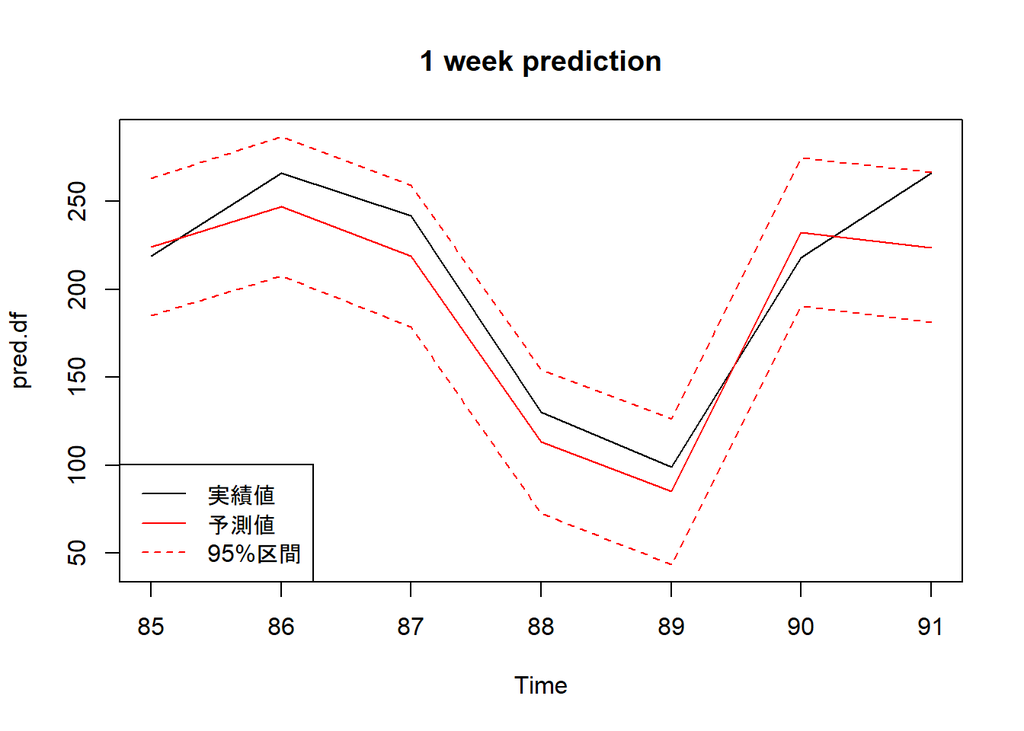

##### 予測力指標

上：MAPE，下：MAE

```
## [1] 0.09741617
## [1] 19.13437
```

## 2. 分析例②

### データ

**醤油の日次販売個数データ**（sec8_DLM.csv）

|  | Date | LogPI_A | LogPriceIndex_A | LogPriceIndex_B | Display_A | Display_B |
| --- | --- | --- | --- | --- | --- | --- |
| 1 | 20000102 | 0.02224561 | 0 | -0.127213 | 0 | 0 |
| 2 | 20000103 | 0.18152188 | 0 | -0.127213 | 0 | 0 |
| 3 | 20000104 | -1.34469081 | 0 | -0.127213 | 0 | 0 |
| 4 | 20000105 | -0.48119082 | 0 | -0.127213 | 0 | 0 |
| 5 | 20000106 | 0.20334092 | 0 | -0.127213 | 0 | 0 |
| 6 | 20000107 | -0.01291622 | 0 | -0.127213 | 0 | 0 |

| 変数名 | 内容 |
| --- | --- |
| Date | 日付（2000/01/02 ~ 2003/09/05，1314日間） |
| LogPI_A | 商品Aの点数PI（来店客1000人当たり販売点数）の対数値 $(y_t)$ |
| LogPriceIndex_A | 商品Aの価格掛率の対数値 $(x_{1t})$ |
| LogPriceIndex_B | 商品Bの価格掛率の対数値 $(x_{2t})$ |
| Display_A | 商品Aの山積み陳列実施の有無 $(x_{3t})$ |
| Display_B | 商品Bの山積み陳列実施の有無 $(x_{4t})$ |

**データ出典**：佐藤 (2016) 『マーケティングの統計モデル』朝倉書店（8章）

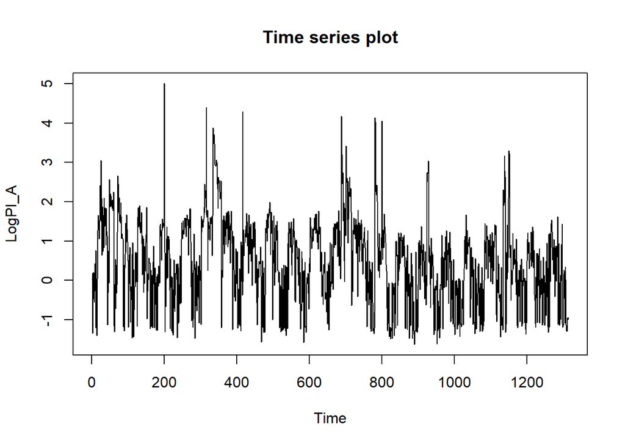

### モデル

#### 観測モデル

$$y_t = \alpha_t + \sum_{j=1}^4 \beta_{j,t} x_{j,t} + \varepsilon_t; \qquad \varepsilon_t \sim N(0, \sigma^2)$$

#### システムモデル

$$\alpha_t = \alpha_{t-1} + v_t; \qquad v_t \sim N(0, \tau^2_\alpha) \\
\beta_{j,t} = \beta_{j,t-1} + \eta_{j,t}; \qquad \eta_{j,t} \sim N(0, \tau^2_j)$$

### Rコード

```r
# データ  は "Import Dataset" で読込済みとする
library(KFAS)

# パラメータ推定
model <- SSModel(LogPI_A ~ SSMtrend(1, Q = NA) +
                   SSMregression(~ LogPriceIndex_A + LogPriceIndex_B + Display_A + Display_B,
                                 Q = diag(NA, 4)),
                 H = NA, data = sec8_DLM)
fit <- fitSSM(model, inits = rep(0,6))
out <- KFS(fit$model)

## 推定結果の図示
plot.df <- cbind(sec8_DLM$LogPI_A, out$alphahat)
colnames(plot.df) <- c("LogPI_A", "Price_A", "Price_B", "Display_A", "Display_B", "trend")
plot(plot.df, main = "Estimaion")
```

マーケティング変数の係数を時変にしているので，分析①とな異なり，`SSMregression` で `Q = diag(NA, 4)` として分散を推定するよう指定していることに注意。 `diag(NA, 4)` は，対角成分が全て欠損値 `NA` でそれ以外は0の対角行列。

#### Rコードの出力

##### 推定結果の図示

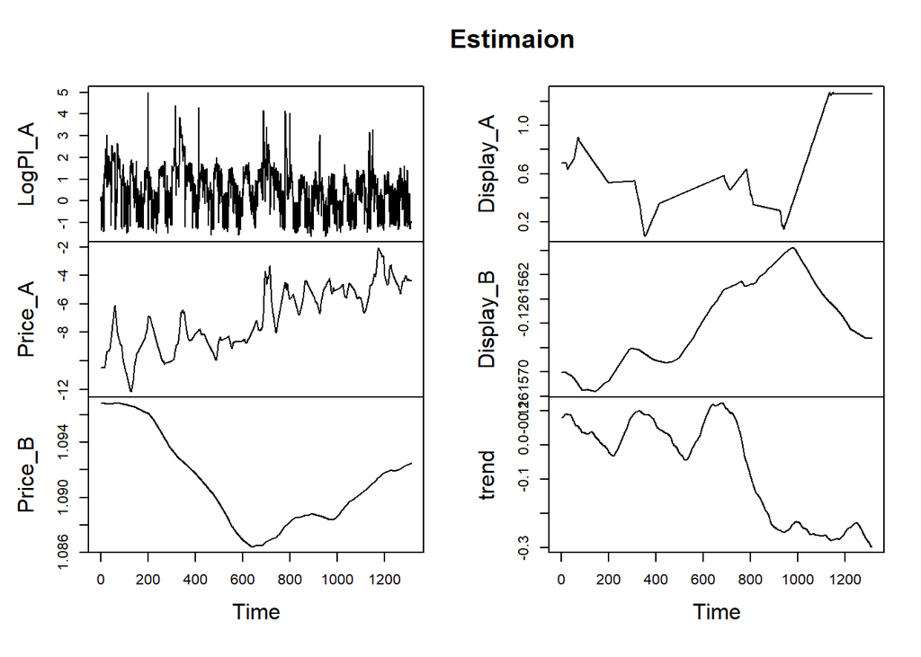